# STAT 435 HW1

Haoran Yu

March 28, 2018

## Problem 1

#### (a)

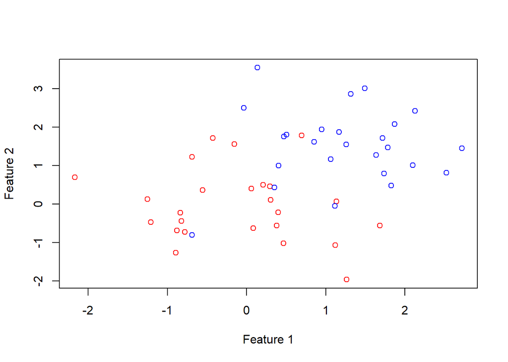

```r
library(MASS)
set.seed(123)
train_red = mvrnorm(25, c(0, 0), diag(2))
train_blue = mvrnorm(25, c(1.5, 1.5), diag(2))
xlim = range(c(train_red[, 1], train_blue[, 1]))
ylim = range(c(train_red[, 2], train_blue[, 2]))
plot(train_red[, 1], train_red[, 2], col = "red", xlim = xlim, ylim = ylim, xlab = 'Feature 1', ylab = 'Feature 2')
points(train_blue[, 1], train_blue[, 2], col = "blue")
```

#### (b)

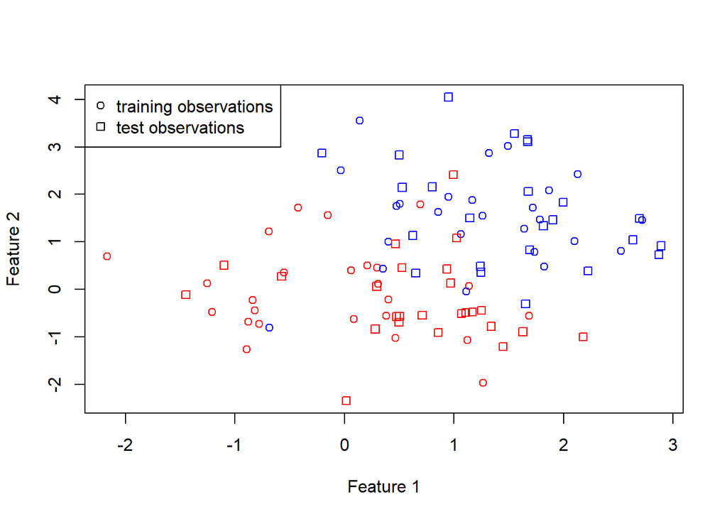

```r
set.seed(1234)
test_red = mvrnorm(25, c(0, 0), diag(2))
test_blue = mvrnorm(25, c(1.5, 1.5), diag(2))
xlim = range(c(train_red[, 1], train_blue[, 1], test_red[, 1], test_blue[, 1]))
ylim = range(c(train_red[, 2], train_blue[, 2], test_red[, 2], test_blue[, 2]))
plot(train_red[, 1], train_red[, 2], col = "red", xlim = xlim, ylim = ylim, xlab = 'Feature 1', ylab = 'Feature 2')
points(train_blue[, 1], train_blue[, 2], col = "blue")
points(test_red[, 1], test_red[, 2], col = "red", pch = 0)
points(test_blue[, 1], test_blue[, 2], col = "blue", pch = 0)
legend('topleft', c('training observations', 'test observations'), pch = c(1, 0))
```

#### (c)

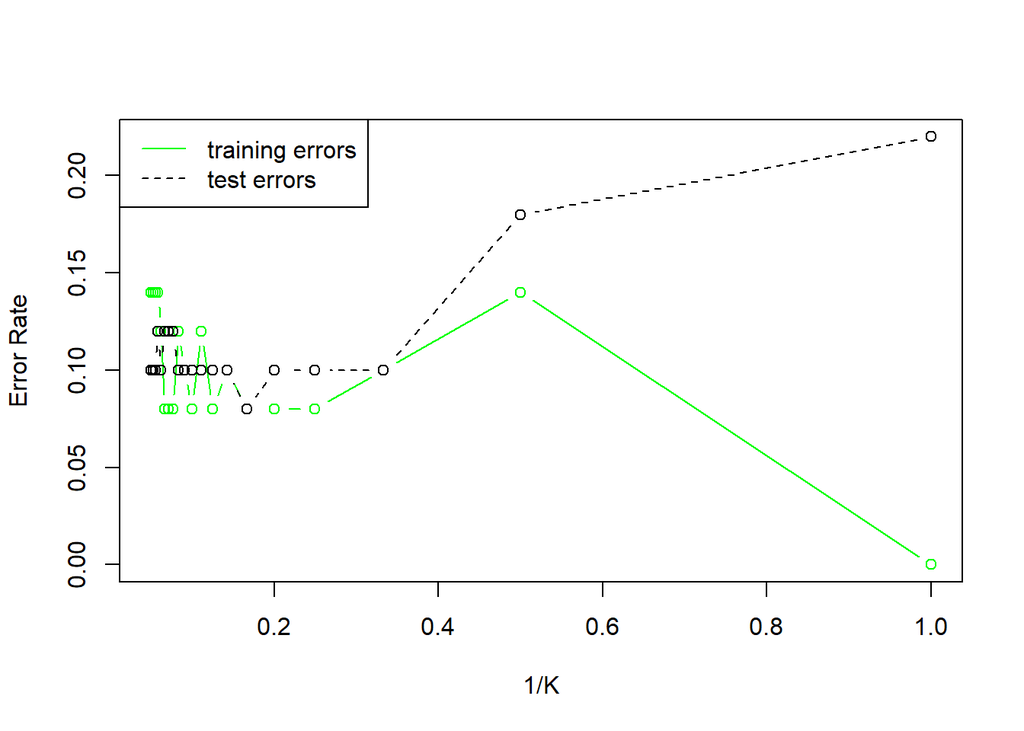

```r
library(class)
train = rbind(train_red, train_blue)
test = rbind(test_red, test_blue)
real = rep(c("red", "blue"), c(25, 25))
error_train = numeric(20)
error_test = numeric(20)
for(i in 1:20){
  pred = knn(train, train, cl = real, k = i)
  error_train[i] = 1 - sum(pred == real) / 50
  pred = knn(train, test, cl = real, k = i)
  error_test[i] = 1 - sum(pred == real) / 50

}
x = 1 / c(1 : 20)
plot(x, error_train, ylim = range(c(error_train, error_test)), type = "b",lty = 1, col = "green", xlab = '1/K', ylab = 'Error Rate')
lines(x, error_test, type = "b",lty = 2, col = "black")
legend('topleft', c('training errors', 'test errors'), col = c("green", "black"), lty = c(1, 2))
```

Explain: As the 1/k increase, the k decrease, which means that the flexibility will increase according to the KNN decision boundary. As the flexibility increase, the training error will decrease monotonically and the test error will first decrease and then increase according to the bias-variance trade-off because the variance will increase and bias will decrease. In this plot, it has decrease but not so obvious.

#### (d)

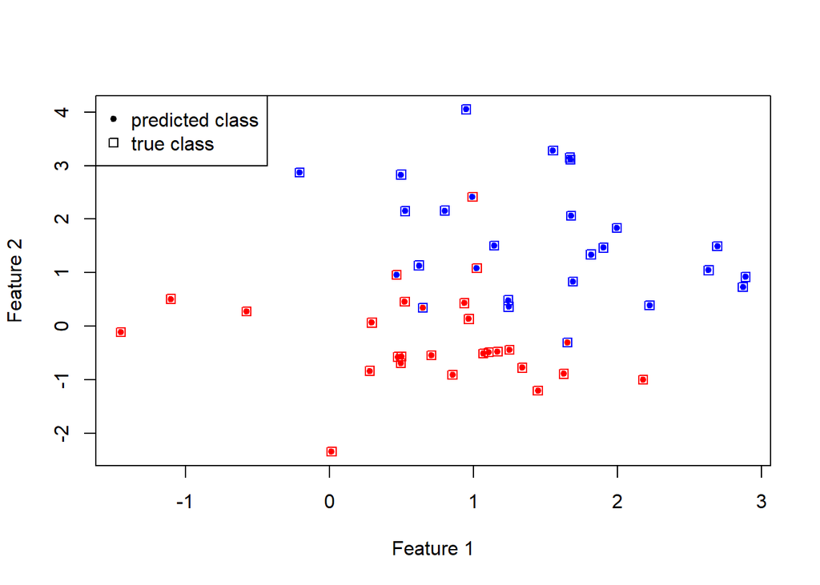

```r
min = error_test[1]
kmin = 1
for(i in 1:20){
  if(min > error_test[i]){
    min = error_test[i]
    kmin = i
  }
}
pred = knn(train, test, cl = real, k = kmin)
plot(test[, 1], test[, 2], col = as.character(pred), pch = 20, xlab = 'Feature 1', ylab = 'Feature 2')
points(test[, 1], test[, 2], col = real, pch = 0)
legend('topleft', c('predicted class', 'true class'), pch = c(20, 0))
```

#### (e)

```r
library(mvtnorm)
pro = numeric(10000)
for(i in 1:10000){
  Y = sample(c("red", "blue"), size = 1)
  if(Y == "red"){
    X = mvrnorm(100, c(0, 0), diag(2))
    pdf_true = dmvnorm(X, c(0, 0), diag(2))
    pdf_wrong = dmvnorm(X, c(1.5, 1.5), diag(2))
  } else {
    X = mvrnorm(100, c(1.5, 1.5), diag(2))
    pdf_wrong = dmvnorm(X, c(0, 0), diag(2))
    pdf_true = dmvnorm(X, c(1.5, 1.5), diag(2))
  }
  time = 0
  for(j in 1:100){
    if(pdf_true[j] > pdf_wrong[j])
      time = time + 1
  }
  pro[i] = time / 100
}
1 - sum(pro)/10000
```

```
## [1] 0.144911
```

The Bayes error rate is nearly 0.144.

Justify: The Bayes error rate is nonzero because there exists an irreducible error. When we generate points from the multivariate normal distribution according labels, it is possblie that the point that is generated is so far from the $\mu$ of the distribution that can be recogized as in the different distribution of the other labels (the pdf of the point in this distribution is smaller than the other distribution). Thus the Bayes error rate exist.

## Problem 2

#### (a)

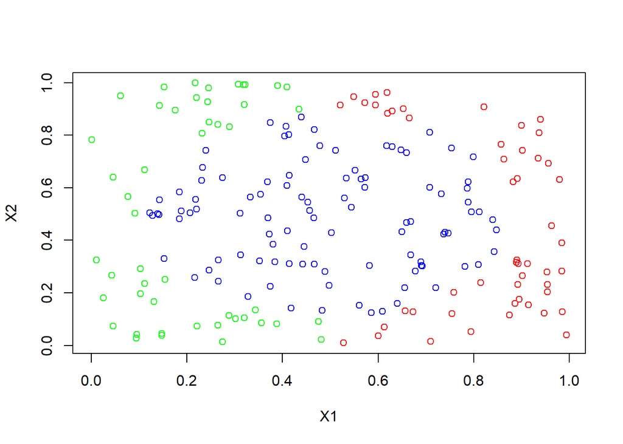

```r
rm(list = ls())
set.seed(123)
train_x1 = runif(200, 0, 1)
set.seed(1234)
train_x2 = runif(200, 0, 1)
train_label = numeric(200)
for(i in 1:200){
  if(((train_x1[i] - 0.5) ^ 2 + (train_x2[i] - 0.5) ^ 2 )> 0.15) {
    if(train_x1[i] > 0.5) {
      train_label[i] = "red"
    } else {
      train_label[i] = "green"
    }
  } else {
    train_label[i] = "blue"
  }
}
plot(train_x1, train_x2, col = train_label, xlab = 'X1', ylab = 'X2')
```

#### (b)

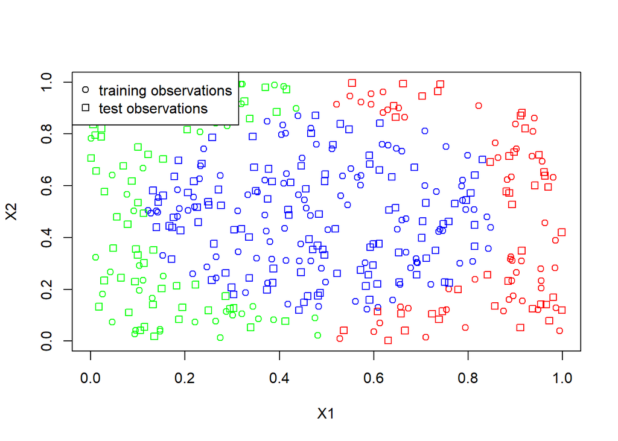

```r
set.seed(246)
test_x1 = runif(200, 0, 1)
set.seed(2468)
test_x2 = runif(200, 0, 1)
test_label = numeric(200)
for(i in 1:200){
  if(((test_x1[i] - 0.5) ^ 2 + (test_x2[i] - 0.5) ^ 2 )> 0.15) {
    if(test_x1[i] > 0.5) {
      test_label[i] = "red"
    } else {
      test_label[i] = "green"
    }
  } else {
    test_label[i] = "blue"
  }
}
plot(train_x1, train_x2, xlim = range(c(train_x1, test_x1)), ylim = range(c(train_x2, test_x2)), col = train_label, xlab = 'X1', ylab = 'X2')
points(test_x1, test_x2, col = test_label, pch = 0)
legend('topleft', c('training observations', 'test observations'), pch = c(1, 0))
```

#### (c)

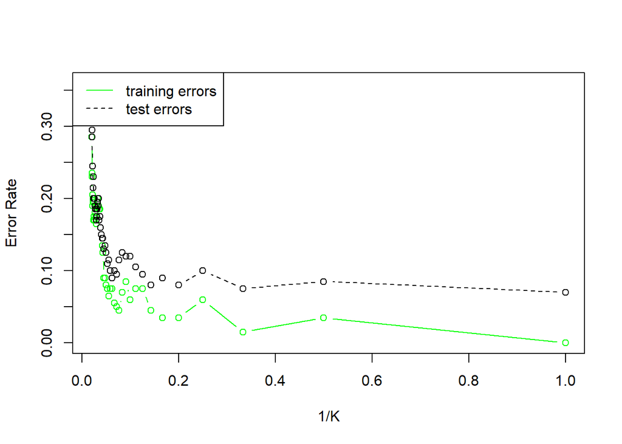

```r
train = cbind(train_x1, train_x2)
test = cbind(test_x1, test_x2)
error_train = numeric(50)
error_test = numeric(50)
for(i in 1:50) {
  pred = knn(train, train, cl = train_label, k = i)
  error_train[i] = 1 - sum(pred == train_label) / 200
  pred = knn(train, test, cl = train_label, k = i)
  error_test[i] = 1 - sum(pred == test_label) / 200
}
x = 1 / c(1:50)
plot(x, error_train, ylim = range(c(error_train, error_test)), type = "b",lty = 1, col = "green", xlab = '1/K', ylab = 'Error Rate')
lines(x, error_test, type = "b",lty = 2, col = "black")
legend('topleft', c('training errors', 'test errors'), col = c("green", "black"), lty = c(1, 2))
```

#### (d)

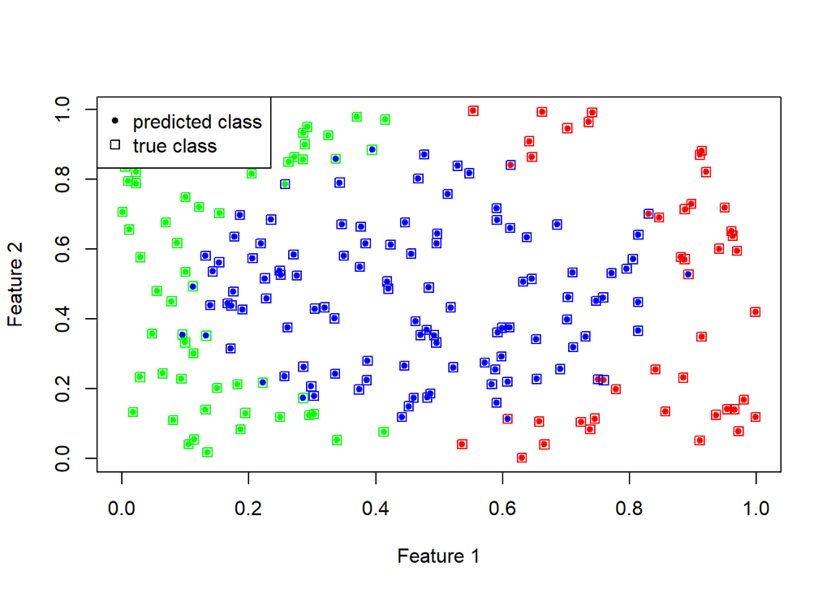

```r
min = error_test[1]
kmin = 1
for(i in 1:50){
  if(min > error_test[i]){
    min = error_test[i]
    kmin = i
  }
}
pred = knn(train, test, cl = train_label, k = kmin)
plot(test[, 1], test[, 2], col = as.character(pred), pch = 20, xlab = 'Feature 1', ylab = 'Feature 2')
points(test[, 1], test[, 2], col = test_label, pch = 0)
legend('topleft', c('predicted class', 'true class'), pch = c(20, 0))
```

#### (e)

The Bayes error rate is 0. It is beacause that for every observation X1 and X2, the Y is fixed, which means that there is no doubt that whether X1 and X2 are belong to this laber or not. The conditional probability will always be 1. Thus the Bayes error rate is 0.